# HW2 - Contrasts

Keanu Rochette

2025-01-28

## Load Libraries

```r
# Data manipulation and visualization
library(tidyverse)
library(here)
library(janitor)
library(ghibli)
library(gt)

# Data analysis/statistics
library(car) #ANOVA
library(ggeffects)
library(effects) #dependency for ggeffects
library(ggResidpanel) #residual panel
library(GGally)
library(emmeans)
```

## Load Data

```r
mesocosm <- read_csv(here("HW2", "data", "HW2_data.csv"))
```

```r
# rename column name for readability
mesocosm<- mesocosm %>%  clean_names() %>%
  rename(np_ratio = nto_pratio)

mesocosm <- mesocosm %>%
  mutate_at(vars(food_web, block, nutrient_level),
            as.factor)
```

## Question 1: Create the linear model

Create a linear model that tests whether richness is explained by nutrient level and/or food web treatment, and whether the effect of food web treatment differs between nutrient levels, while also accounting for the blocked structure of the experiment. Why is it important to account for the blocks? Analyze the results of the linear model as we did in Homework 1. What is your interpretation of these results so far?

### Creating a linear model

```r
mesocosm_q1_lm <- lm(phyto_chao1 ~ nutrient_level*food_web + block, data = mesocosm )

summary(mesocosm_q1_lm)
```

```
##
## Call:
## lm(formula = phyto_chao1 ~ nutrient_level * food_web + block,
##     data = mesocosm)
##
## Residuals:
##     Min      1Q  Median      3Q     Max
## -7.9575 -3.1031  0.1463  2.2300  9.2563
##
## Coefficients:
##                           Estimate Std. Error t value Pr(>|t|)
## (Intercept)                10.7437     2.3171   4.637 6.48e-05 ***
## nutrient_levelL             2.3912     2.6524   0.902   0.3745
## food_webG                   6.1100     2.6524   2.304   0.0284 *
## food_webP                  -0.3990     2.9133  -0.137   0.8920
## block2                     -0.1676     2.1969  -0.076   0.9397
## block3                     -0.9499     2.1048  -0.451   0.6550
## block4                     -1.6725     2.3149  -0.722   0.4756
## nutrient_levelL:food_webG   0.7125     3.7948   0.188   0.8523
## nutrient_levelL:food_webP   5.1877     3.9864   1.301   0.2030
## ---
## Signif. codes:  0 '***' 0.001 '**' 0.01 '*' 0.05 '.' 0.1 ' ' 1
##
## Residual standard error: 4.885 on 30 degrees of freedom
## Multiple R-squared:  0.4046, Adjusted R-squared:  0.2458
## F-statistic: 2.548 on 8 and 30 DF,  p-value: 0.03008
```

#### ANOVA()

```r
Anova(mesocosm_q1_lm)
```

```
## Anova Table (Type II tests)
##
## Response: phyto_chao1
##                         Sum Sq Df F value   Pr(>F)
## nutrient_level          163.07  1  6.8341 0.013853 *
## food_web                314.91  2  6.5985 0.004217 **
## block                    14.80  3  0.2068 0.890886
## nutrient_level:food_web  45.82  2  0.9601 0.394315
## Residuals               715.86 30
## ---
## Signif. codes:  0 '***' 0.001 '**' 0.01 '*' 0.05 '.' 0.1 ' ' 1
```

#### Effects plot

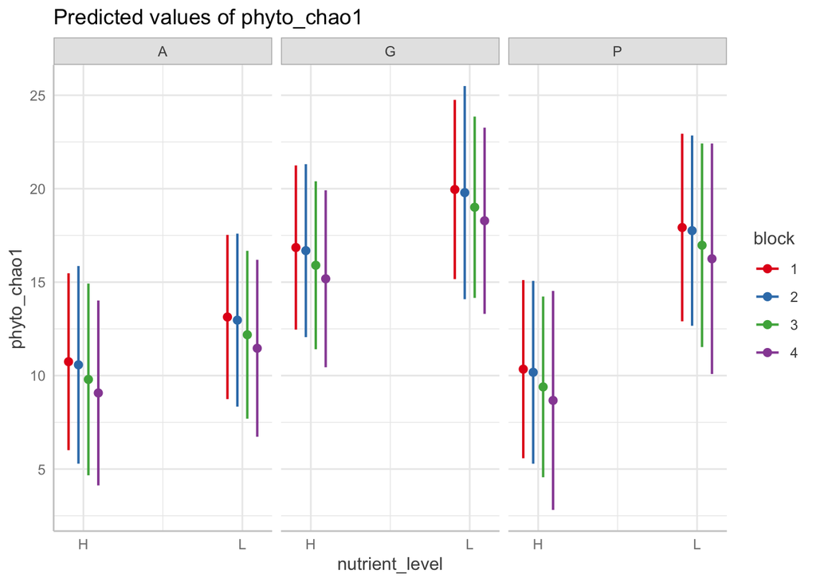

```r
plot(ggeffect(mesocosm_q1_lm, terms = c("nutrient_level", "block","food_web" )))
```